**Linear Time-Invariant (LTI) Systems**

By Prof. Seungchul Lee  
http://iai.postech.ac.kr/  
Industrial AI Lab at POSTECH

Table of Contents

# 1. Linear Time-Invariant (LTI) Systems

## 1.1. Systems

A discrete-time system $\mathcal{H}$ is a transformation (a rule or formula) that maps a discrete-time input signal $x$ into a discrete-time output signal $y$

[figure not shown]

## 1.2 Linear Systems

A system $\mathcal{H}$ is **linear** if it satisfies the following two properties:

**1) Scaling** $$\mathcal{H}\{ \alpha x \} = \alpha \mathcal{H} \quad \forall \, \alpha \in \mathbb{C}$$

[figure not shown]

**2) Additivity**

$$ \text{If}\,\, y_1 = \mathcal{H} \{ x_1 \} \,\, \text{and}\,\, y_2 = \mathcal{H} \{ x_2 \} \, \, \text{then } \mathcal{H} \{x_1 + x_2\} = y_1 + y_2$$

[figure not shown]

## 1.3 Time-Invariant Systems

A system $\mathcal{H}$ processing infinite-length signals is **time-invariant** (shift-invariant) if a time shift of the input signal creates a corresponding time shift in the output signal

[figure not shown]

## 1.4. Linear Time-Invariant (LTI) Systems

We usally consider **Linear Time-Invariant (LTI)** systems.

# 2. Convolution

$$y[n] = \sum \limits_{m=-\infty}^{\infty} h[n - m]\,x[m] = x[n]*h[n]$$

Output $y[n]$ came out by convolution of input $x[n]$ and system $h[n]$

```matlab
%%html
<center><iframe src="https://www.youtube.com/embed/Ma0YONjMZLI?rel=0"
width="560" height="315" frameborder="0" allowfullscreen></iframe></center>
```

[video not shown]

## 2.1. Convolution in Matrix (= Toeplitz Matrices)

For Infinite-Length Signals

$$y[n] = x[n]*h[n] = \sum \limits_{m=-\infty}^{\infty} h[n - m]\,x[m] $$

$$ = \cdots \,h[n+2]\,x[-2] + h[n+1]\,x[-1] + h[n]\,x[0] + h[n-1]\,x[1] + h[n-2]\,x[2]\, \cdots $$

It is inner product of $h$ vectors and $x$

$$ \begin{align*} y[n] &= \begin{bmatrix} \cdots & \bracevert & \bracevert & \bracevert & \bracevert & \bracevert & \cdots\\ \cdots & h[n+2] & h[n+1] & h[n] & h[n-1] & h[n-2]\ & \cdots\\ \cdots & \bracevert & \bracevert & \bracevert & \bracevert & \bracevert & \cdots \end{bmatrix} \begin{bmatrix} \vdots\\ x[-2]\\ x[-1]\\ x[0]\\ x[1]\\ x[2]\\ \vdots \end{bmatrix}\\ \\ &= H x \end{align*} $$

Convolution is product of matrix $H$ and $x$

[figure not shown]

$$h = h[0]$$

## 2.2. Impulse Response

(impulse) : $\delta[n] = \begin{cases} 1 \quad n = 0\\ 0 \quad \text{otherwise}\\ \end{cases}$

[figure not shown]

# 3. Convolution Examples

Convolution = filtering in time domain

## 3.1. Convolution Demo

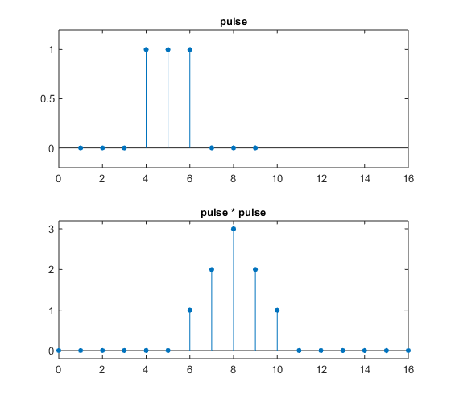

```matlab
%plot -s 560,500

% Convolve a rectangular pulse with itself

% pulse
x = [0 0 0 1 1 1 0 0 0];

% convolve pulse with itself
y = conv(x,x);

n = 0:length(y)-1;

subplot(2,1,1)
stem(x,'filled','markersize',4); axis([0 16 -0.2 1.2]);
title('pulse','fontsize',10)

subplot(2,1,2)
stem(n,y,'filled','markersize',4); axis([0 16 -0.2 3.2]);
title('pulse * pulse','fontsize',10)
```

## 3.2. Denoising a Piecewise Smooth Signal

- moving average (MA) filter
- low-pass filter in time domain

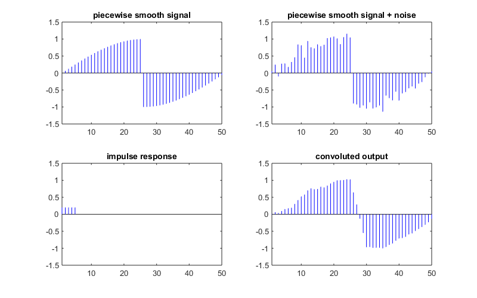

```matlab
%plot -s 800,500

% piecewise smooth signal
N = 50;
n = 0:N-1;

x = sin(pi/N*n)'.*[ones(N/2,1); -ones(N/2,1)];
xn = x + 0.1*randn(N,1);

% construct moving average filter impulse response of length M
M = 5;
h = zeros(N,1);
h(1:M) = 1/M;

% convolve noisy signal with impulse response
y = conv(xn,h);

subplot(2,2,1), stem(x,'b','Marker','none');
axis([1 N -1.5 1.5]), title('piecewise smooth signal')

subplot(2,2,2), stem(xn,'b','Marker','none');
axis([1 N -1.5 1.5]), title('piecewise smooth signal + noise')

subplot(2,2,3), stem(h,'b','Marker','none');
axis([1 N -1.5 1.5]), title('impulse response')

subplot(2,2,4), stem(y,'b','Marker','none'), xlim([1,N])
axis([1 N -1.5 1.5]), title('convoluted output')
```

## 3.3. Edge Detection

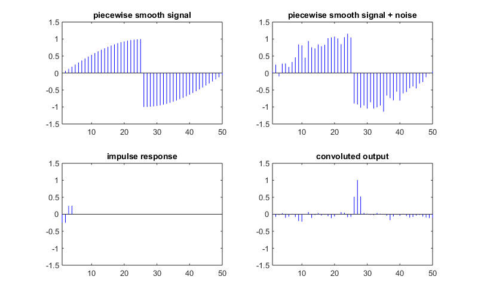

```matlab
%plot -s 800,500

% haar wavelet edge detector
M = 4;
h = zeros(N,1);
h(1:2) = -1/M;
h(3:4) = 1/M;

% convolve noisy signal with impulse response
y = conv(xn,h);

subplot(2,2,1), stem(x,'b','Marker','none');
axis([1 N -1.5 1.5]), title('piecewise smooth signal')

subplot(2,2,2), stem(xn,'b','Marker','none');
axis([1 N -1.5 1.5]), title('piecewise smooth signal + noise')

subplot(2,2,3), stem(h,'b','Marker','none');
axis([1 N -1.5 1.5]), title('impulse response')

subplot(2,2,4), stem(y,'b','Marker','none'), xlim([1,N])
axis([1 N -1.5 1.5]), title('convoluted output')
```

```matlab
%%html
<center><iframe src="https://www.youtube.com/embed/I3isHB9Iy7E?rel=0"
width="560" height="315" frameborder="0" allowfullscreen></iframe></center>
```

[video not shown]

```matlab
%%html
<center><iframe src="https://www.youtube.com/embed/ZW6pw89cuEA?rel=0"
width="560" height="315" frameborder="0" allowfullscreen></iframe></center>
```

[video not shown]

## 3.4. Convolution on Audio

```matlab
[x, Fs] = audioread('.\data_files\violin_origional.wav');

x = x/max(x);  % normalize
sound(x, Fs);  % play a wave file with sampling rate Fs
```

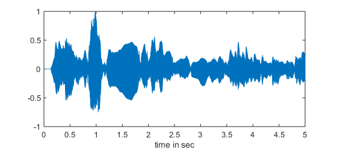

```matlab
%plot -s 560,250

% plot wave file
plot((1:length(x))/Fs,x), xlabel('time in sec')
```

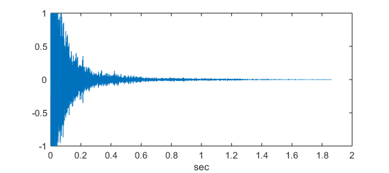

```matlab
%% impulse response in a closed room (by gunshot)

[h, Fs] = audioread('.\data_files\gunshot.wav');

sound(h, Fs);

plot((1:length(h))/Fs, h), xlabel('sec')
```

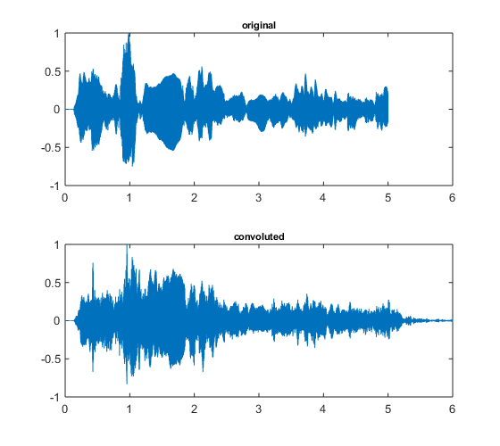

```matlab
%plot -s 560,500

y = conv(x,h);
y = y/max(y);

subplot(2,1,1), plot((1:length(x))/Fs,x), xlim([0 6]), title('original','fontsize',8)
subplot(2,1,2), plot((1:length(y))/Fs,y), xlim([0 6]), title('convoluted','fontsize',8)
```

```matlab
% image how the music played in a closed room sounds like

sound(y, Fs);
```

# 4. *Non-linear* System: Median Filter

$$ y[n] = \text{median}\{x[n-k],\cdots,x[n+k]\}$$

- There are nonlinear neighborhood operations that can be perfromed for the purpose of noise reduction that can do a better job of preserving edges than simple smoothing filters.
- Median filters can do an excellent job of rejecting certain types of noise, in particular, "shot" or impulse noise (outlier in a time series) in which some individual pixels or signals have extreme values.

## 4.1. Removing Shot Noise in Audio

```matlab
[x, Fs] = audioread('.\data_files\violin_origional.wav');

x = x/max(x); % normalize
sound(x, Fs)  % play a wave file with sampling rate Fs
```

```matlab
% generate an audio signal with a salt and pepper noise

shot_noise = imnoise(zeros(length(x),1),'salt & pepper',0.04);
x_noise = x + shot_noise - mean(shot_noise);

sound(x_noise,Fs)
```

```matlab
% apply a linear low-pass filter

h = [1,1,1]/3;
x_avg = conv(h,x_noise);
sound(x_avg,Fs)

% does not work very well
```

```matlab
% apply a nonlinear filter

x_median = medfilt1(x_noise,7);
sound(x_median,Fs)

% WOW !!!
```

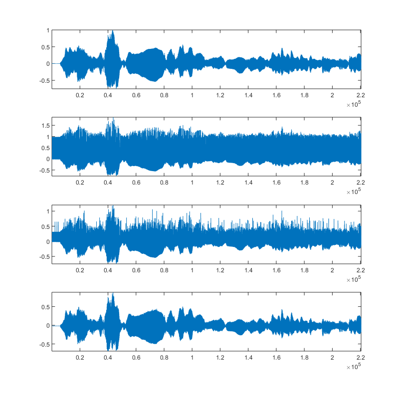

```matlab
%plot -s 800,800

subplot(4,1,1), plot(x); axis tight
subplot(4,1,2), plot(x_noise); axis tight
subplot(4,1,3), plot(x_avg); axis tight
subplot(4,1,4), plot(x_median); axis tight
```

```matlab
%%javascript
$.getScript('https://kmahelona.github.io/ipython_notebook_goodies/ipython_notebook_toc.js')
```